# Practical Machine Learning Project

Van Wyk Burnett

10/04/2020

## Synopsis

This report will evaluate a database of measures recorded on how 6 participants perform the exercise “Unilateral Dumbbell Biceps Curl”.

This database will be used to build a prediction model using the classifcation trees, random forests and gradient boosting methods. Random forests will prove to predict the outcome (classe) with the best accuracy and this model that were built will then be used to predict the test set, the test set is also provided.

## Data Processing

Loading in training data

```r
traindata <- read.csv(url("https://d396qusza40orc.cloudfront.net/predmachlearn/pml-training.csv"),header=T, sep = ",")
dim(traindata)
```

```
## [1] 19622   160
```

Loading in test data

```r
testdata <- read.csv(url("https://d396qusza40orc.cloudfront.net/predmachlearn/pml-testing.csv"), header=TRUE, sep=",")
dim(testdata)
```

```
## [1]  20 160
```

## Exploratory Data Analysis

```r
unique(traindata$classe)
```

```
## [1] A B C D E
## Levels: A B C D E
```

Unilateral Dumbbell Biceps Curl in five different fashions: Class A - exactly according to the specification, Class B - throwing the elbows to the front, Class C - lifting the dumbbell only halfway, Class D - lowering the dumbbell only halfway and Class E - throwing the hips to the front.

Check for columns with missing data

```r
suppressPackageStartupMessages(library(dplyr))
missingvals <- sapply(traindata, function(traindata)sum(is.na(traindata)))
missingvals <- as.data.frame(missingvals)
names(missingvals) <- c("Sum")
missingvaltable <- missingvals != 0
missingvalfinal <- subset(missingvaltable, missingvaltable == TRUE)
dim(missingvalfinal)
```

```
## [1] 67  1
```

This indicates 67 columns that have missing values.

These columns are:

```r
removecols <- rownames(missingvalfinal)
removecols
```

```
##  [1] "max_roll_belt"            "max_picth_belt"
##  [3] "min_roll_belt"            "min_pitch_belt"
##  [5] "amplitude_roll_belt"      "amplitude_pitch_belt"
##  [7] "var_total_accel_belt"     "avg_roll_belt"
##  [9] "stddev_roll_belt"         "var_roll_belt"
## [11] "avg_pitch_belt"           "stddev_pitch_belt"
## [13] "var_pitch_belt"           "avg_yaw_belt"
## [15] "stddev_yaw_belt"          "var_yaw_belt"
## [17] "var_accel_arm"            "avg_roll_arm"
## [19] "stddev_roll_arm"          "var_roll_arm"
## [21] "avg_pitch_arm"            "stddev_pitch_arm"
## [23] "var_pitch_arm"            "avg_yaw_arm"
## [25] "stddev_yaw_arm"           "var_yaw_arm"
## [27] "max_roll_arm"             "max_picth_arm"
## [29] "max_yaw_arm"              "min_roll_arm"
```

[output cut: 19 more lines]

```r
traindata <- traindata[,!(names(traindata) %in% removecols)]
dim(traindata)
```

```
## [1] 19622    93
```

We will do the same for the testdata

```r
testdata <- testdata[,colSums(is.na(testdata)) == 0]
dim(testdata)
```

```
## [1] 20 60
```

Now we can remove columns that have little impact in the variable “Classe”. THe first seven columns provide information about the people who dod the test and the timestamps, these columns can be removed.

```r
traindata <- traindata[,-c(1:7)]
dim(traindata)
```

```
## [1] 19622    86
```

```r
testdata <- testdata[, -c(1:7)]
dim(testdata)
```

```
## [1] 20 53
```

Remove variables with near-zero variance

```r
library(caret)
NZV <- nearZeroVar(traindata)
traindata <- traindata[, -NZV]
dim(traindata)
```

```
## [1] 19622    53
```

## Preparing data for prediction

We will need to split the traindata into a training data set and a test set we will call this; train_train and train_test. The split will be 70% for train_train and 03% for train_test.

```r
set.seed(315)
inTrain <- createDataPartition(traindata$classe, p = 0.7, list = FALSE)
train_train <- traindata[inTrain, ]
train_test <- traindata[-inTrain, ]
dim(train_train)
```

```
## [1] 13737    53
```

```r
dim(train_test)
```

```
## [1] 5885   53
```

#Classification tree

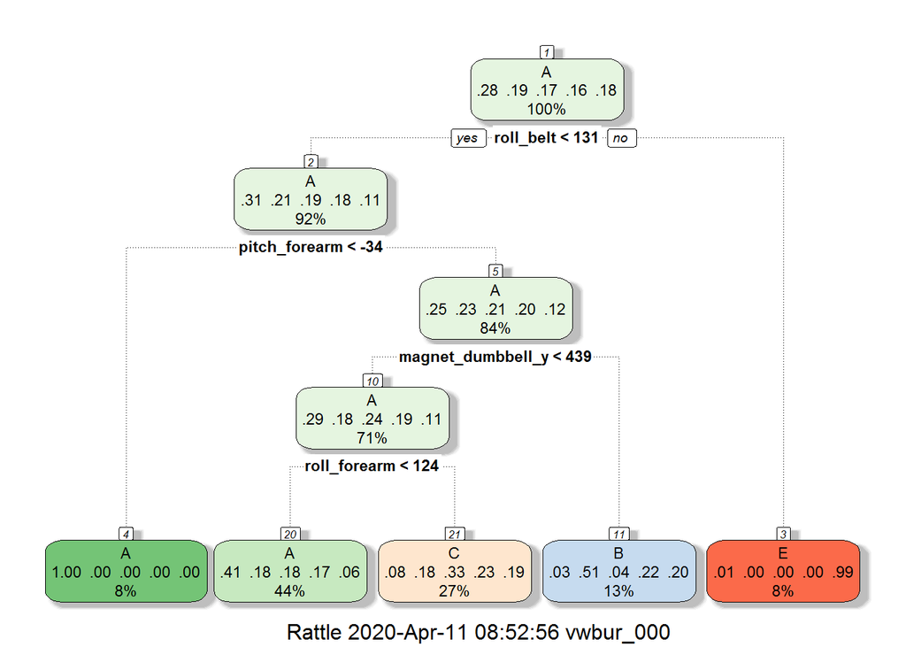

```r
suppressPackageStartupMessages(library(rattle))
suppressPackageStartupMessages(library(rpart.plot))
trControl<- trainControl(method = "cv", number=5)
Tree1 <- train(classe ~ .,data=train_train, method="rpart", trControl = trControl)
fancyRpartPlot(Tree1$finalModel)
```

```r
trainpred <- predict(Tree1, newdata = train_test)
cmatrix <- confusionMatrix(train_test$classe, trainpred)
cmatrix$table
```

```
##           Reference
## Prediction    A    B    C    D    E
##          A 1513   33  126    0    2
##          B  476  370  293    0    0
##          C  489   29  508    0    0
##          D  420  175  369    0    0
##          E  171  134  288    0  489
```

```r
cmatrix$overall[1]
```

```
##  Accuracy
## 0.4893798
```

The accuracy of this model is very low at 48.94%, thus the outcome “classe” will not be predictd very well by the predictors that we considered.

Now we will use the random forests algoritm to see if we can get a better accuracy.

#Random Forest

```r
suppressPackageStartupMessages(library(randomForest))
forest1 <- train(classe~., data=train_train, method = "rf", trControl=trControl)
```

```r
print(forest1)
```

```
## Random Forest
##
## 13737 samples
##    52 predictor
##     5 classes: 'A', 'B', 'C', 'D', 'E'
##
## No pre-processing
## Resampling: Cross-Validated (5 fold)
## Summary of sample sizes: 10989, 10991, 10990, 10989, 10989
## Resampling results across tuning parameters:
##
##   mtry  Accuracy   Kappa
##    2    0.9905365  0.9880283
##   27    0.9911913  0.9888569
##   52    0.9828196  0.9782653
##
## Accuracy was used to select the optimal model using the largest value.
## The final value used for the model was mtry = 27.
```

Accuracy by number of predictors.

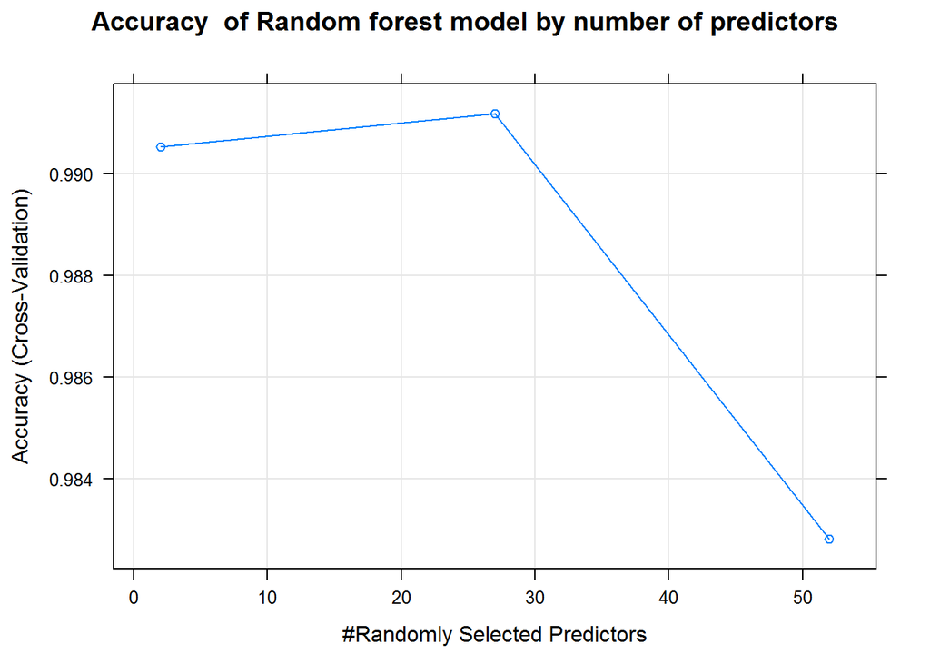

```r
plot(forest1, main="Accuracy  of Random forest model by number of predictors")
```

```r
trainFpred <- predict(forest1, newdata=train_test)
cmatrixF <- confusionMatrix(train_test$classe, trainFpred)
cmatrixF$table
```

```
##           Reference
## Prediction    A    B    C    D    E
##          A 1672    1    1    0    0
##          B    8 1127    4    0    0
##          C    0    6 1017    3    0
##          D    0    1   10  953    0
##          E    0    0    2    1 1079
```

```r
cmatrixF$overall[1]
```

```
##  Accuracy
## 0.9937128
```

```r
names(forest1$finalModel)
```

```
##  [1] "call"            "type"            "predicted"       "err.rate"
##  [5] "confusion"       "votes"           "oob.times"       "classes"
##  [9] "importance"      "importanceSD"    "localImportance" "proximity"
## [13] "ntree"           "mtry"            "forest"          "y"
## [17] "test"            "inbag"           "xNames"          "problemType"
## [21] "tuneValue"       "obsLevels"       "param"
```

```r
forest1$finalModel$classe
```

```
## [1] "A" "B" "C" "D" "E"
```

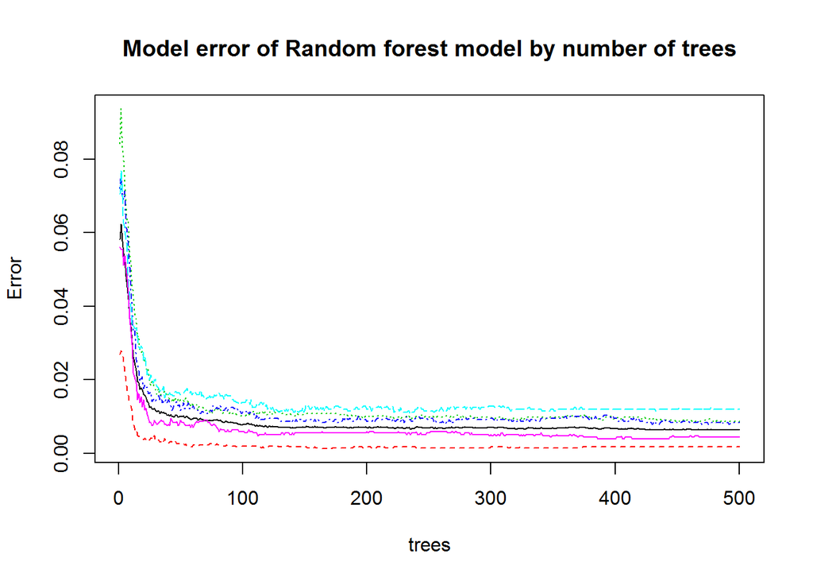

```r
plot(forest1$finalModel, main = "Model error of Random forest model by number of trees")
```

```r
MostImpVars <- varImp(forest1)
MostImpVars
```

```
## rf variable importance
##
##   only 20 most important variables shown (out of 52)
##
##                      Overall
## roll_belt            100.000
## pitch_forearm         56.928
## yaw_belt              52.153
## magnet_dumbbell_y     44.469
## roll_forearm          43.445
## pitch_belt            42.488
## magnet_dumbbell_z     41.694
## accel_dumbbell_y      23.163
## magnet_dumbbell_x     16.266
## accel_forearm_x       16.153
## magnet_belt_z         15.721
## roll_dumbbell         15.699
## accel_belt_z          13.990
## total_accel_dumbbell  13.811
## accel_dumbbell_z      13.245
## magnet_forearm_z      13.196
## magnet_belt_y         11.168
## yaw_arm               10.531
## gyros_belt_z          10.124
## magnet_belt_x          9.535
```

In the graph “Accuracy by Random forest model by number of predictors” we can see that the oprimal number of predictor is 27. There might be some dependencies between the predictors.

Let’s considert the gradient boosting method for prediction.

#Gradient boosting method

```r
library(gbm)
boost1 <- train(classe ~ .,data = train_train, method = "gbm", trControl = trControl)
```

```r
print(boost1)
```

```
## Stochastic Gradient Boosting
##
## 13737 samples
##    52 predictor
##     5 classes: 'A', 'B', 'C', 'D', 'E'
##
## No pre-processing
## Resampling: Cross-Validated (5 fold)
## Summary of sample sizes: 10990, 10991, 10989, 10990, 10988
## Resampling results across tuning parameters:
##
##   interaction.depth  n.trees  Accuracy   Kappa
##   1                   50      0.7551855  0.6897185
##   1                  100      0.8209934  0.7734393
##   1                  150      0.8541881  0.8155195
##   2                   50      0.8559360  0.8175114
##   2                  100      0.9062382  0.8813368
##   2                  150      0.9309159  0.9125660
##   3                   50      0.8955370  0.8677603
##   3                  100      0.9414716  0.9259324
##   3                  150      0.9606904  0.9502650
##
## Tuning parameter 'shrinkage' was held constant at a value of 0.1
##
## Tuning parameter 'n.minobsinnode' was held constant at a value of 10
## Accuracy was used to select the optimal model using the largest value.
## The final values used for the model were n.trees = 150, interaction.depth =
##  3, shrinkage = 0.1 and n.minobsinnode = 10.
```

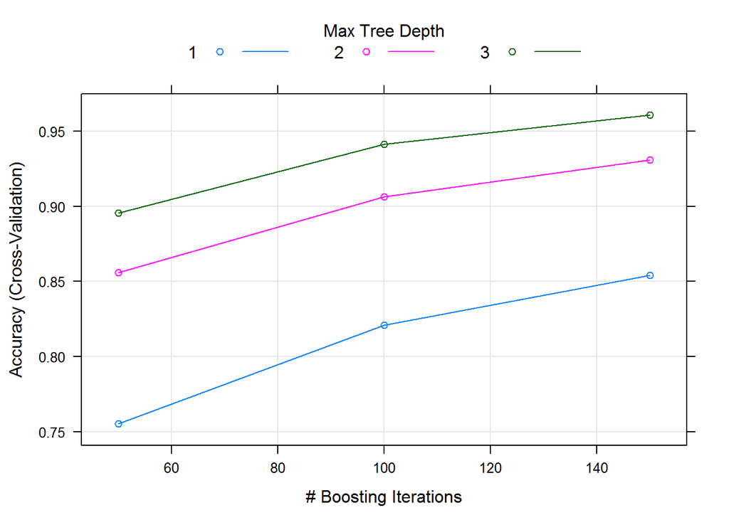

```r
plot(boost1)
```

```r
trainBpred <- predict(boost1, newdata=train_test)
cmatrixB <- confusionMatrix(train_test$classe, trainBpred)
cmatrixB$table
```

```
##           Reference
## Prediction    A    B    C    D    E
##          A 1638   18   11    5    2
##          B   35 1062   42    0    0
##          C    0   29  985   10    2
##          D    2    5   46  908    3
##          E    1   13    8   14 1046
```

```r
cmatrixB$overall[1]
```

```
##  Accuracy
## 0.9581988
```

```r
FinalPrediction <- predict(forest1, newdata=testdata)
FinalPrediction
```

```
##  [1] B A B A A E D B A A B C B A E E A B B B
## Levels: A B C D E
```